# Intro to Deep Learning 1

Se define la *inteligencia* como la capacidad de procesar información para poder predecir o tomar decisiones; la **Inteligencia Artificial** es la habilidad de que las computadoras lo realicen. **Machine Learning** es un campo de IA que se enfoca en enseñar a un algoritmo cómo aprender de datos previos. **Deep Learning** es un campo de ML, enfocado en el uso de redes neuronales para extraer características y patrones de los datos.

## Deep Learning

Tradicionalmente, las características de los datos que queremos clasificar se realiza de forma manual, una persona observa los datos y dependiendo de su naturaleza se extraen características y patrones. En Deep Learning estas características se obtienen de forma jerárquica, por ejemplo, si queremos reconocer caras, podemos primero reconocer bordes; después buscar ojos, bocas, etc., y finalmente poder reconocer rostros.

Con el aumento de las bases de datos y mejoras en el hardware y software, fue que se hizo posible el auge del Deep Learning.

## Perceptrón

Un pereptrón es una sola neurona, que realiza una operación sobre una serie de entradas. En un perceptrón cada una de las **entradas** se multiplica por sus **pesos**, que indica qué tanto influye una entrada en la salida de la neurona, luego cada una de las entradas multiplicadas por sus pesos se **suman** y se le aplica una **función de activación**, esta función de activación debe ser no lineal para poder clasificar puntos que no puedan separarse por una línea recta; finalmente la salida de nuestra neurona es la aplicación de la función de activación a la suma más un **bias**, que nos permite mover la activación de la neurona en números diferentes a 0. Sea $\hat{y}$ la salida de nuestra neurona, $x_i$ las entradas, $w_i$ los pesos de las entradas y $w_0$ el bias tenemos:

$$ \hat{y} = g(w_0 + \sum_{i=1}^{m}x_i w_i) $$

O de forma matricial:

$$ \hat{y} = g(w_0 + \mathbf{X}^T\mathbf{W}) $$

### Múltiples salidas

Podemos agregar más de un perceptrón, donde definimos a $z_i$ como:

$$ z_i = w_{0,i} + \sum_{j=1}^{m} x_j w_{j,i} $$

donde $i$ indica a qué neurona pertenece cada bias y peso, de manera que $w_{0,1}$ es el bias de la neurona 1. Así la salda del perceptrón con más de una salida serán las funciones de activación aplicadas a cada $z_i$:

$$ y_i = g(z_i) $$

### Red neuronal de una capa

Si agregamos $n$ neuronas de la forma anterior, tenemos una red neuronal de una capa oculta, esto se llama así porque no observamos directamente qué es lo que pasa en cada $z_i$. Una red densa o completamente conectada es aquella donde cada neurona de la capa oculta está conectada a todas las entradas.

### Red neuronal profunda

Podemso agregar $k$ capas ocultas entre la entrada y la salida y tendremos una red neuronal profunda.

## Entrenamiento

Al crear una red neuronal, esta no tiene los parámetros óptimos para dar respuestas correctas, por lo que tiene que entrenarse. El **costo** de una red mide qué tan grave es que nuestra red cometa errores al predecir. Este es una función que toma las salidas de nuestra red y las salidas correctas.

$$ J(W) = \frac{1}{n} \sum_{i=1}^{n} \mathcal{L}(f(x^{(i)}; W), y^{(i)}) $$

## Optimización

Nuestro costo es una función, de forma que podemos encontrar el gradiente que nos indica la dirección en la que debemos avanzar para maximizarlo, pero si vamos en la dirección opuesta, entonces podemos minimizarlo, haciendo el error más pequeño. A esto se le denomina **gradiente descendiente**. Para ello primero se inicializa de forma aleatoria la red y se van obteniendo los gradientes. El pseudocódigo es:

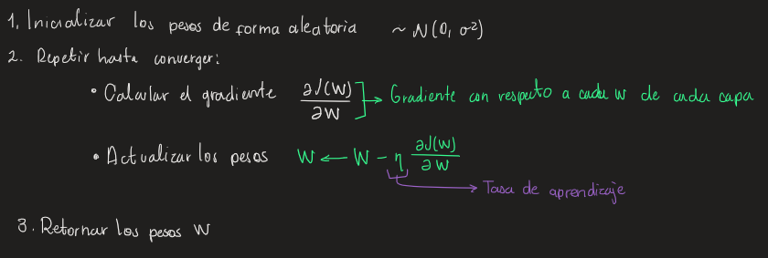

### Backpropagation

Es la forma en la que se calculan los gradientes, utilizando la regla de la cadena. Este proceso se realiza para cada uno de los pesos, y nos indica qué tanto influye cada uno de los pesos en nuestra función de costo.

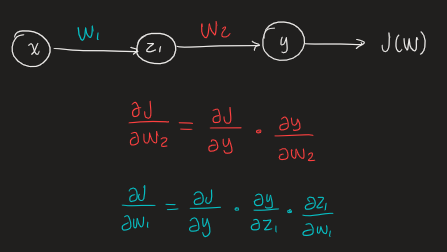

### Tasa de aprendizaje

La tasa de aprendizaje es importante para llegar al mínimo de nuestra función, si tomamos una tasa muy pequeña, es posible que nos quedemos atascados en un mínimo local, mientras que si tomamos una demasiado grande, puede que se desestabilice o que nos encontremos oscilando entre dos puntos.

Para mejorar este parámetro podemos realizar alguna de las siguientes acciones:

1. Probar con diferentes tasas de aprendizaje.
2. Hacer que la tasa de aprendizaje cambie de forma que se *adapte* a la pendiente.

## Mini lotes

El gradiente es computacionalmente costoso, por lo que una forma de optimizar este proceso es dividir nuestros ejemplos en lotes. Entonces se realiza el mismo algoritmo de gradiente descendiente, pero ahora sobre un subconjunto de nuestros datos. Se pueden usar lotes de 32 ejemplos o hasta 100, dependiendo del poder computacional. Al hacer esto, se puede paralelizar el proceso, distribuyendo los lotes en diferentes unidades de procesamiento y así obtener resultados más rápidos.

## Sobreajuste y regularización

Es un problema común en Machine Learning. Cuando entrenamos un modelos que se aproxime a nuestros datos, queremos una función que se aproxime a todos estos puntos. El problema del sobreajuste se presenta cuando la función mapea a todos los puntos de forma precisa, lo que da la desventaja de que si se presentan nuevos datos, entonces lo más probable es que el modelo haga predicciones erróneas. El exteremo opuesto es considerar una función muy simple de forma que tiene un error muy grande al aproximarse a los datos de ejemplo.

La **regularización** es una técnica para descartar modelos complejos, así podemos dar resultados correctos para datos que nuestro modelo nunca ha visto.

### Dropout

Consiste en poner en 0 algunas de las funciones de activación, generalmente se hace con el 50%. Este método permite que la red no dependa tanto de aquellas neuronas que se eliminaron.

### Early stopping

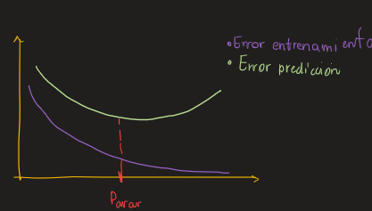

# Modelado secuencial

Si nos dan la tarea de a partir de una imagen determinar la dirección de una pelota, la respuesta que daremos será una aleatoria, pero si se nos dan imágenes previas de la pelota, entonces podremos predecir con mayor exactitud su trayectoria futura. Algunos otros datos secuenciales son:

- Audio como una secuencia señales sonoras.
- Texto, como una secuencia de caracteres o palabras.
- Señales médicas como ECG.
- Secuencias de ADN.

## Modelos

- **Uno a uno**: Puede ser clasificación binaria, donde tenemos ua entrada y una salida que nos da una de dos opciones.
- **Muchos a uno**: Tenemos muchas entradas y nos da una salida, por ejemplo tenemos una secuencia de palabras y queremos clasificar la oración completa en algún sentimiento.
- **Uno a muchos**: Una entrada y muchas salidas, por ejemplo tenemos como entrada una imagen y de salida una secuencia de palabras que describen la imagen.
- **Muchos a muchos**: Muchas entradas y muchas salidas, por ejemplo al traducir un texto.

## Redes neuronales

Podemos tomar una red neuronal de una capa la cual represente nuestros datos en un tiempo $t$, entonces para diferentes tiempos vamos a tener diferentes salidas.

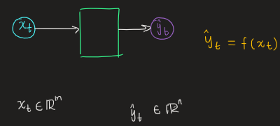

Si nuestros datos son una secuencia, entonces cada salida a un tiempo $t$ depende de las salidas previas. Esto se logra conectando la información de tiempos previos al actual mediante una *relación de recurrencia*, donde tenemos un *estado* para cada tiempo denominado $h_t$. Entonces ahora la salida no depende sólo de la entrada actual, sino que también depende del estado anterior de la forma:

$$ \hat{y_t} = f(x_t, h_{t-1}) $$

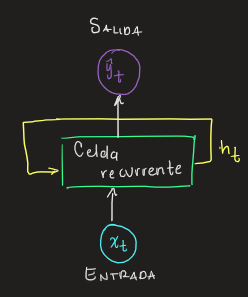

## Redes neuronales recurrentes (RNNs)

Las RNNs tienen estados que se actualizan en cada instante de tiempo. Para actualizar estos estados, utilizamos la siguiente relación:

$$ h(t) = f_W(x_t, h_{t-1}) $$

Donde $f_W$ es una función parametrizada por una serie de pesos $W$, los cuales son los mismos para cada paso en el tiempo y la función es la misma. Para actualizar los estados se realiza una operación como la que sigue:

$$ h_t = \tanh({\mathbf{W}^T_{hh}h_{t-1} + \mathbf{W}^T_{xh}x_t}) $$

Multiplicamos el estado anterior por una matriz de pesos y la entrada actual por otra matriz de pesos, finalmente aplicando una función no lineal. Estas dos matrices son independientes. Luego nuestra salida será la siguiente:

$$ \hat{y} = \mathbf{W}^T_{hy} h_t $$

## Entrenamiento

Para optimizar los pesos, podemos tener un costo para cada instante de tiempo $L_t$ y finalmente obtener el costo total sumando todos los costos individuales en cada instante de tiempo.

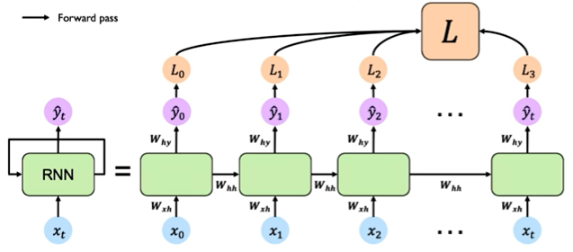

## Criterios de diseño

Para modelar secuencias se debe cumplir:

- Poder manejar secuencias de longitud variable
- Seguir dependencias a largo plazo.
- Mantener información acerca del orden. Se debe diferenciar entre diferentes formas de ordenar nuestros datos, ya que cambia la salida.
- Compartir parámetros a lo largo de las secuencias.

## Predecir palabras

Para representar palabras y usarlas en una red, debemos poder operarlas de forma matemática. Una forma de codificarlas es transformarlas a un vector de tamaño fijo. Por ejemplo, tenemos como inicio un conjunto de palabras que forman nuestro vocabulario, las palabras que vamos a identificar. Una vez que tengamos esto, podemos dar a cada palabra un índice, el cual se puede mapear a un vector de 1s y 0s. Por ejemplo, la palabra con el índice uno se representaría como [0 0 0 ... 1] lo que se denomina *codificación one-hot*. Otra forma forma es usar algún modelo de ML para codificar las palabras, así aquellas palabras que tengan significados similares se codifican de una forma muy parecida.

## Backpropagation a través del tiempo

Para hacer backpropagation en RNNs debemos hacerlo primero para cada tiempo $t$ y luego a través de todos los tiempos, desde el tiempo actual hasta el inicio de la secuencia. Para calcular los gradientes, tenemos que pasar por muchas multiplicaciones matriciales, lo que hace que el gradiente crezca exponencialmente, a lo que se le denomina **exploding gradients**. Por otra parte, si tenemos gradientes muy pequeños, entonces estos comenzarán a disminuir exponencialmente, lo que se denomina **vanishing gradients**. Este último es problemático ya que hace que el error en aquellos tiempos más distantes tengan menor relevancia.

Para poder prevenir el desvanecimiento del gradiente se deben tomar en cuenta los siguientes parámetros:

- **Función de activación**: La función ReLU es una buena función de activación.
- **Inicialización de los pesos**: Se pude inicializar a la matriz de identidad.
- **Arquitectura de la red neuronal**: Se pueden utilizar diferentes unidades como *gated cells*, que selectivamente añade o remueve información del estado de la red. Una de estas arquitecturas es la red LSTM (Long Short Term Memory), las cuales son capaces de rastrear información a través de diferentes tiempos. Esta red elimina información que no es relevante y almacena información relevante, de esta manera actualiza los estados de las celdas de forma selectiva y la salida es una versión filtrada. Así al realizar backpropagation se tiene más estabilidad.

## Limitaciones

- Al codificar los datos en una forma que pueda ser operada por una red neuronal, se pierde algo de información que puede ser valiosa.
- Modelos recurrentes no son eficientes, tardan mucho tiempo y no pueden paraleliarse ya que cada salida depende de la anterior.
- No se tiene memoria a largo plazo.

Entonces lo que queremos alcanzar con un modelo secuencial es tener un flujo continuo de los datos, que pueda ser paralelizable y que tenga memoria a largo plazo.

Una forma que puede solucionar esto es tomar todos los puntos a través del tiempo y condensarla en un vector de entradas, con una matriz de características con toda la información de todas las entradas y un vector de salidas, pero esto no es escalable, entonces no podemos cambiar la longitud de la secuencia, tampoco tenemos noción de orden y no tendríamos memoria a largo plazo.

## Transformers

La forma de solucionar los problemas anteriores es mediante la **atención**. Lo primero es la atención propia, que significa tomar una entrada y atender las partes más importantes de esta. Para esto se realiza una *búsqueda*.

1. Codificar los datos en una manera que se tenga una noción de posición.
2. Extraer *query, key, value* para la búsqueda. Es lo que se quiere buscar, qué resultados son similares a lo que queremos buscar y finalmente extraer la información de los valores con mayor atención.

[figure not shown]

1. Obtener la atención. La puntuación de atención es obtener la similaridad entre query y key. Una forma de medir esto es mediante el producto punto y dividirlo sobre una escala $\frac{Q \cdot K^T}{escala}$ y finalmente se aplica la función $softmax$ que pasa el resultado a un rango de [0,1].
2. Extraer los valores con mayor atención mediante la multiplicación de nuestra atención por los valores.